# AN588-Week-10

Now, let’s fit a “line” of best fit through our data, along with 95% CI around this “line”. We want to plot the relationship between success (rather than log success) and age, so this relationship will not actually be linear but log-linear.

```r
x <- data.frame(age = seq(from = 5, to = 17, length.out = 30))
prediction <- cbind(age = x, predict(glm, newdata = x, type = "response", se = TRUE))
# IMPORTANT: Using the argument type='response' makes our prediction be
# units of our actual Y variable (success) rather than log(success)
prediction$LL <- prediction$fit - 1.96 * prediction$se.fit
prediction$UL <- prediction$fit + 1.96 * prediction$se.fit
head(prediction)
```

```
##        age      fit    se.fit residual.scale       LL       UL
## 1 5.000000 8.465986 0.8711054              1 6.758619 10.17335
## 2 5.413793 8.675922 0.8413401              1 7.026895 10.32495
## 3 5.827586 8.891064 0.8101102              1 7.303248 10.47888
## 4 6.241379 9.111541 0.7774904              1 7.587660 10.63542
## 5 6.655172 9.337485 0.7435987              1 7.880031 10.79494
## 6 7.068966 9.569032 0.7086127              1 8.180151 10.95791
```

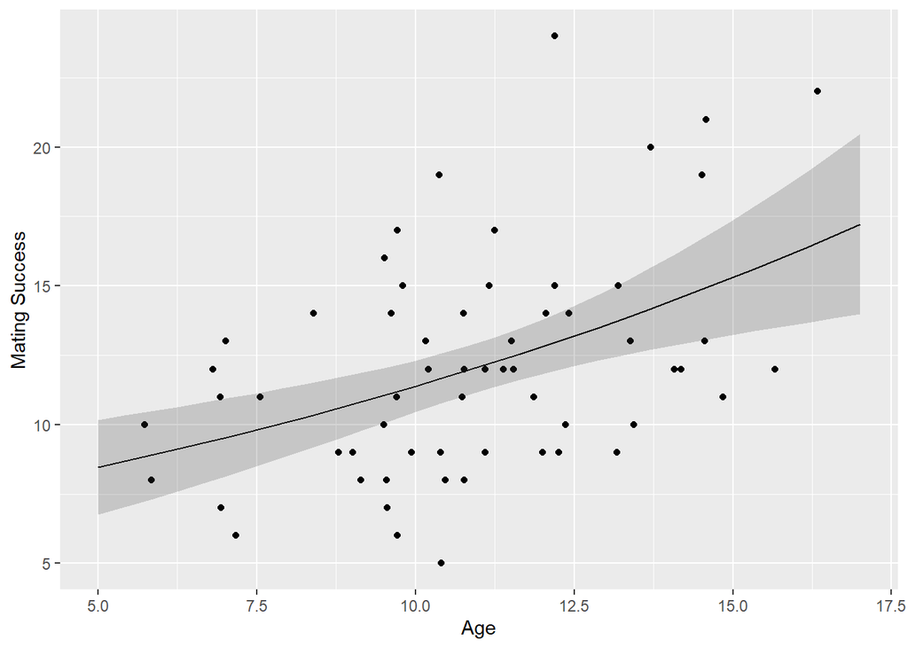

```r
p <- p + geom_line(data = prediction, aes(x = age, y = fit)) + geom_ribbon(data = prediction,
    aes(x = age, y = fit, ymin = LL, ymax = UL), alpha = 0.2) + xlab("Age") +
    ylab("Mating Success")
p  # note the curvilinear 'line' of best fit
```

Is this model better than an intercept-only model? YES! We can see this by doing a likelihood ratio test.

```r
glm1 <- glm(data = d, success ~ 1, family = "poisson")
glm2 <- glm(data = d, success ~ age, family = "poisson")
# using the anova function
anova(glm1, glm2, test = "Chisq")
```

```
## Analysis of Deviance Table
##
## Model 1: success ~ 1
## Model 2: success ~ age
##   Resid. Df Resid. Dev Df Deviance  Pr(>Chi)
## 1        59     75.972
## 2        58     61.179  1   14.794 0.0001199 ***
## ---
## Signif. codes:  0 '***' 0.001 '**' 0.01 '*' 0.05 '.' 0.1 ' ' 1
```

```r
# based on the deviance between a specified null and full models
x2 <- glm1$deviance - glm2$deviance
x2
```

```
## [1] 14.79362
```

```r
p <- 1 - pchisq(x2, df = 1)
p
```

```
## [1] 0.0001199407
```

```r
# based on hand calculating deviance for each model; logLik() function
# returns the log-likelihood of a model
Dglm1 = -2 * logLik(glm1)
Dglm1
```

```
## 'log Lik.' 333.6736 (df=1)
```

```r
Dglm2 = -2 * logLik(glm2)
Dglm2
```

```
## 'log Lik.' 318.8799 (df=2)
```

```r
x2 <- as.numeric(Dglm1 - Dglm2)
x2
```

```
## [1] 14.79362
```

```r
p <- 1 - pchisq(x2, df = 1)  # df = difference in number of parameters in the full verus reduced model
p
```

```
## [1] 0.0001199407
```

As mentioned briefly in Module 16, the Akaike Information Criterion, or AIC, is another way of evaluating and comparing related models. For similar models, those with lower AIC models are preferred over those with higher AIC. The AIC value is based on the deviance associated with the model, but it penalizes model complexity. Much like an adjusted R-squared, it’s intent is to prevent you from including irrelevant predictors when choosing among similar models. Models with low AICs represent a better fit to the data, and if many models have similarly low AICs, you should choose the one with the fewest model terms. For both continuous and categorical predictors, we prefer comparing full and reduced models against one another to test individual terms rather than comparing the fit of all possible models to try and select the “best” one. Thus, AIC values are useful for comparing models, but they are not interpretable on their own. The logLik() function returns the log-likelihood associated with a particular model and can be used to calculate AIC values by hand.

```r
AIC <- 2 * 2 - 2 * logLik(glm2)  # formula for AIC = 2 * # params estimated - 2 * log-likelihood of model; for thise model we estimated 2 params
AIC
```

```
## 'log Lik.' 322.8799 (df=2)
```

```r
AICreduced <- 2 * 1 - 2 * logLik(glm1)  # for this model, 1 param is estimated
AICreduced
```

```
## 'log Lik.' 335.6736 (df=1)
```

### Challenge 3

Using the woolly monkey mating success data set, explore multiple Poisson regression models of [a] mating success in relation to rank and [b] mating success in relation to age + rank (and their interaction) on your own. What conclusions can you come to about the importance of rank and rank in combination with age versus age alone?

```r
# glm of success~age
glm1 <- glm(data = d, success ~ rank, family = "poisson")
summary(glm1)
```

```
##
## Call:
## glm(formula = success ~ rank, family = "poisson", data = d)
##
## Deviance Residuals:
##     Min       1Q   Median       3Q      Max
## -2.4470  -0.8424  -0.1774   0.4721   2.8432
##
## Coefficients:
##             Estimate Std. Error z value Pr(>|z|)
## (Intercept)  2.53568    0.05745  44.138   <2e-16 ***
## ranklow     -0.17247    0.08498  -2.029   0.0424 *
## rankmedium   0.10931    0.09601   1.139   0.2549
## ---
## Signif. codes:  0 '***' 0.001 '**' 0.01 '*' 0.05 '.' 0.1 ' ' 1
##
## (Dispersion parameter for poisson family taken to be 1)
##
##     Null deviance: 75.972  on 59  degrees of freedom
## Residual deviance: 67.229  on 57  degrees of freedom
## AIC: 330.93
##
## Number of Fisher Scoring iterations: 4
```

```r
coeffs <- glm1$coefficients
coeffs
```

```
## (Intercept)     ranklow  rankmedium
##   2.5356790  -0.1724693   0.1093131
```

```r
CIs <- confint(glm1, level = 0.95)
CIs
```

```
##                   2.5 %       97.5 %
## (Intercept)  2.42092563  2.646198893
## ranklow     -0.33952605 -0.006209755
## rankmedium  -0.08068136  0.295948462
```

```r
# glm of success~age+rank
glm2 <- glm(data = d, success ~ age + rank, family = "poisson")
summary(glm2)
```

```
##
## Call:
## glm(formula = success ~ age + rank, family = "poisson", data = d)
##
## Deviance Residuals:
##     Min       1Q   Median       3Q      Max
## -2.3631  -0.7242  -0.1271   0.6126   2.5314
##
## Coefficients:
##             Estimate Std. Error z value Pr(>|z|)
## (Intercept)  1.89985    0.18016  10.546  < 2e-16 ***
## age          0.05848    0.01547   3.780 0.000157 ***
## ranklow     -0.18419    0.08504  -2.166 0.030324 *
## rankmedium   0.07981    0.09633   0.829 0.407344
## ---
## Signif. codes:  0 '***' 0.001 '**' 0.01 '*' 0.05 '.' 0.1 ' ' 1
##
## (Dispersion parameter for poisson family taken to be 1)
##
##     Null deviance: 75.972  on 59  degrees of freedom
## Residual deviance: 52.905  on 56  degrees of freedom
## AIC: 318.61
##
## Number of Fisher Scoring iterations: 4
```

```r
coeffs <- glm2$coefficients
coeffs
```

```
## (Intercept)         age     ranklow  rankmedium
##  1.89985210  0.05848079 -0.18418827  0.07981313
```

```r
CIs <- confint(glm2, level = 0.95)
CIs
```

```
##                  2.5 %      97.5 %
## (Intercept)  1.5439316  2.25019524
## age          0.0281809  0.08882429
## ranklow     -0.3513638 -0.01780910
## rankmedium  -0.1107918  0.26708124
```

```r
# glm of success~age+rank+age:rank
glm3 <- glm(data = d, success ~ age * rank, family = "poisson")
summary(glm3)
```

```
##
## Call:
## glm(formula = success ~ age * rank, family = "poisson", data = d)
##
## Deviance Residuals:
##      Min        1Q    Median        3Q       Max
## -2.32160  -0.74018  -0.05743   0.61891   2.44260
##
## Coefficients:
##                Estimate Std. Error z value Pr(>|z|)
## (Intercept)     1.68099    0.27350   6.146 7.93e-10 ***
## age             0.07821    0.02398   3.261  0.00111 **
## ranklow         0.35253    0.39958   0.882  0.37763
## rankmedium      0.19221    0.47173   0.407  0.68368
## age:ranklow    -0.04820    0.03514  -1.372  0.17009
## age:rankmedium -0.01052    0.04037  -0.261  0.79432
## ---
## Signif. codes:  0 '***' 0.001 '**' 0.01 '*' 0.05 '.' 0.1 ' ' 1
##
## (Dispersion parameter for poisson family taken to be 1)
##
##     Null deviance: 75.972  on 59  degrees of freedom
## Residual deviance: 50.925  on 54  degrees of freedom
## AIC: 320.63
##
## Number of Fisher Scoring iterations: 4
```

```r
coeffs <- glm3$coefficients
coeffs
```

```
##    (Intercept)            age        ranklow     rankmedium    age:ranklow
##     1.68098680     0.07820855     0.35253499     0.19220655    -0.04820457
## age:rankmedium
##    -0.01052473
```

```r
CIs <- confint(glm3, level = 0.95)
CIs
```

```
##                      2.5 %     97.5 %
## (Intercept)     1.14024776 2.21228299
## age             0.03107609 0.12507067
## ranklow        -0.43334404 1.13330517
## rankmedium     -0.74201052 1.10847589
## age:ranklow    -0.11693019 0.02081384
## age:rankmedium -0.08936412 0.06896883
```